# RNASeq Pipeline

Emily Nissen

2022-09-28

# Pre-processing

## FastQC

Run FastQC to check quality of data.

Run on fastq file for each sample (if paired-end data, run on two fastq files for each sample)

https://www.bioinformatics.babraham.ac.uk/projects/fastqc/

```bash
fastqc -o path_to_fastqc_output_folder/fastqc/ -f fastq -t 8 path_to_data_folder/sample1_R1.fastq.gz
fastqc -o path_to_fastqc_output_folder/fastqc/ -f fastq -t 8 path_to_data_folder/sample1_R2.fastq.gz
```

## MultiQC

FastQC outputs individual document for each fastq file. MultiQC will aggregate all files. Input is the folder where all FastQC reports are.

https://multiqc.info/

```bash
multiqc --interactive path-to-fastqc-output-folder/
```

## Trimming

Only trim if needed. Usually adaptor content shows up in FastQC reports.

I typically use trimmomatic: http://www.usadellab.org/cms/?page=trimmomatic

Or Trim Galore!: https://www.bioinformatics.babraham.ac.uk/projects/trim_galore/

Trimming for Illumina universal adapters

```bash
java -jar Trimmomatic-0.39/trimmomatic-0.39.jar PE -threads 8 \
path_to_data_folder/sample1_R1.fastq.gz \
path_to_data_folder/sample1_R2.fastq.gz \
path_to_data_folder/sample1_R1_paired.fastq.gz \
path_to_data_folder/sample1_R1_unpaired.fastq.gz \
path_to_data_folder/sample1_R2_paired.fastq.gz \
path_to_data_folder/sample1_R2_unpaired.fastq.gz \
ILLUMINACLIP://Trimmomatic-0.39/adapters/TruSeq3-PE-2:2:30:10 Leading:3 TRAILING:3 SLIDINGWINDOW:4:15 MINLEN:31
```

```bash
TrimGalore-0.6.6/trim_galore --paired \
-a AGATCGGAAGAGC -a2 AAATCAAAAAAAC \
path_to_data_folder/sample1_R1.fastq.gz \
path_to_data_folder/sample1_R2.fastq.gz \
```

## Aligning

RSEM aligns to the transcriptome. Use rsem-prepare-reference to setup and index transcriptome for the organism and aligner you plan on using (this only needs to be done once). Then you can run rsem-calculate-expression to calculate expression values.

https://github.com/deweylab/RSEM

https://deweylab.github.io/RSEM/rsem-calculate-expression.html

This code will output two results files for each sample “sampleN.genes.results” and “sampleN.isoforms.results”. The “sampleN.genes.results” are the expression values aggregated at the gene level. The “expected_count” column is what is needed for input in to a differential expression analysis.

rsem-calculate-expression [options] –paired-end upstream_read_file(s) downstream_read_file(s) reference_name sample_name

```bash
mkdir path_to_rsem_results/rsemResults/rsemResult_sample1

rsem-calculate-expression \
# number of threads
-p 8 \
# aligner
--bowtie2 \
--paired-end \
# generate BAM files
--output-genome-bam \
# strandedness will depend on how the libraries were prepared, default is is none
--strandedness reverse \
# upstream read file
path_to_data_folder/sample1_R1.fastq.gz \
# downstream read file
path_to_data_folder/sample1_R2.fastq.gz \
# reference_name
path_to_reference/ucsc-hg38-rsem/hg38-rsem \
#sample_name, all output files are prefixed by this name
path_to_rsem_results/rsemResults/rsemResult_sample1/sample1
```

```bash
rsem-generate-data matrix \
# list all gene.results files
path_to_rsem_results/rsemResults/rsemResults_sample1/sample1.genes.results \
path_to_rsem_results/rsemResults/rsemResults_sample2/sample2.genes.results \
path_to_rsem_results/rsemResults/rsemResults_sampleN/sampleN.genes.results > genes.count.matrix
```

## MultiQC

Run multiqc again to add on mapping statistics

```bash
multiqc --interactive path_to_folder_that_has_fastqcfolder_and_rsemfolder/
```

# Differential Expression Analysis

https://bioconductor.org/packages/release/bioc/html/edgeR.html

## Setup

```r
#load any packages here
library(edgeR)
library(ggplot2)
library(dplyr)
library(org.Hs.eg.db)
library(gage)
library(pathview)
library(aliases2entrez)
library(data.table)
library(ggrepel)
library(Glimma)
library(ggpubr)
library(Rtsne)
library(UpSetR)
library(grid)
library(tidyr)
library(clusterProfiler)
library(pheatmap)
library(ggridges)
library(enrichplot)
library(ggvenn)
library(ReactomePA)

# helpful functions
source("utils_RNASeq.R")
```

## Load Data and Format as edgeR Object

```r
counts = read.table("genes.count.matrix", header = T, sep = "\t", row.names = 1, check.names = F)

pheno = read.csv("SampleSheet.csv")

all(colnames(counts) == pheno$Sample.Name)
```

```
## [1] TRUE
```

```r
# group should be whatever the experimental groups of interest are
# here I am using Cell Type (mMDSC vs Monocyte)
group = pheno$Cell.Type

# create DGEList object
y = DGEList(counts, group = factor(group))

# filter lowly expressed genes
# n is the sample size of the smallest experiment group
n = 4
# only keep genes that have more than 1 CPM in more than n samples
keep = rowSums(cpm(y)>1) >= n
sum(keep)
```

```
## [1] 12347
```

```r
y = y[keep,]
dim(y)
```

```
## [1] 12347     8
```

```r
# calculate scaling factors to convert raw library sizes into effective library sizes
y = calcNormFactors(y)
```

## Data Exploration

```r
pca = prcomp(t(as.matrix(y$counts)), scale = T)
summary(pca)
```

```
## Importance of components:
##                            PC1     PC2     PC3      PC4      PC5      PC6
## Standard deviation     65.1923 52.3744 50.9011 34.45310 24.89431 23.72616
## Proportion of Variance  0.3442  0.2222  0.2098  0.09614  0.05019  0.04559
## Cumulative Proportion   0.3442  0.5664  0.7762  0.87236  0.92255  0.96815
##                             PC7       PC8
## Standard deviation     19.83153 1.494e-13
## Proportion of Variance  0.03185 0.000e+00
## Cumulative Proportion   1.00000 1.000e+00
```

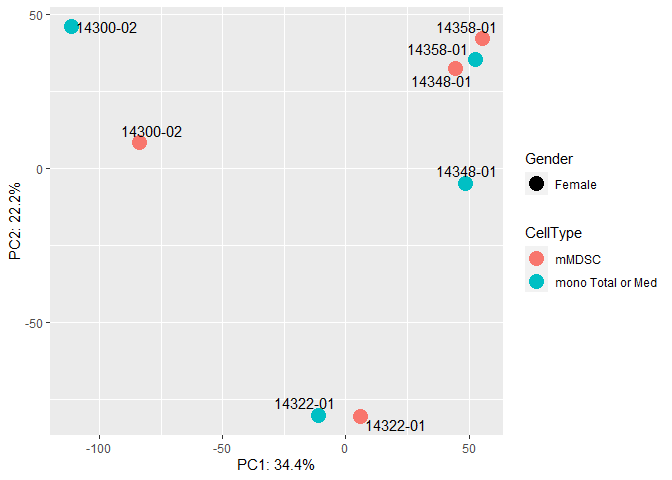

```r
var_explained = pca$sdev^2/sum(pca$sdev^2)

df=as.data.frame(cbind(pca$x[,1], pca$x[,2], pca$x[,3], pca$x[,4]))
colnames(df)=c('PC1','PC2','PC3','PC4')
# add variables that might explain variation
df$Sample = colnames(counts)
df$CellType = pheno$Cell.Type
df$Gender = pheno$Gender
df$ID = pheno$Sampling.ID

df %>%
  ggplot(aes(x=PC1,y=PC2))+
  geom_point(aes(color = CellType, shape = Gender), size=5) +
  geom_text_repel(aes(label=ID)) +
  labs(x=paste0("PC1: ",round(var_explained[1]*100,1),"%"),
       y=paste0("PC2: ",round(var_explained[2]*100,1),"%"))
```

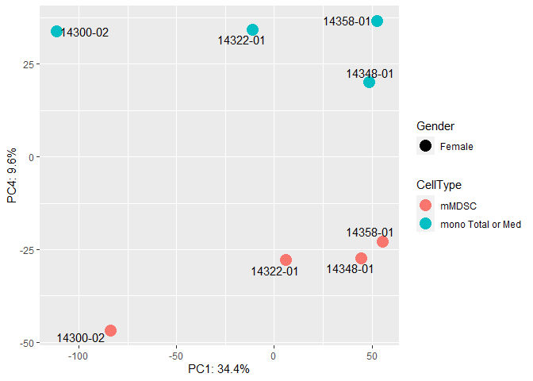

```r
df %>%
  ggplot(aes(x=PC1,y=PC4))+
  geom_point(aes(color = CellType, shape = Gender), size=5) +
  geom_text_repel(aes(label=ID)) +
  labs(x=paste0("PC1: ",round(var_explained[1]*100,1),"%"),
       y=paste0("PC4: ",round(var_explained[4]*100,1),"%"))
```

## Testing for Differential Expression

### Paired Design

This is testing under a paired sample design

```r
ID = factor(pheno$Sampling.ID)
Cell.Type = factor(pheno$Cell.Type)
Cell.Type = relevel(Cell.Type, ref = "mono Total or Med")
# design matrix
design = model.matrix(~ID + Cell.Type)
rownames(design) = colnames(y)
design
```

```
##     (Intercept) ID14322-01 ID14348-01 ID14358-01 Cell.TypemMDSC
## 1R            1          0          0          0              1
## 2R            1          0          0          0              0
## 7R            1          1          0          0              1
## 8R            1          1          0          0              0
## 20R           1          0          1          0              1
## 21R           1          0          1          0              0
## 27R           1          0          0          1              1
## 28R           1          0          0          1              0
## attr(,"assign")
## [1] 0 1 1 1 2
## attr(,"contrasts")
## attr(,"contrasts")$ID
## [1] "contr.treatment"
##
## attr(,"contrasts")$Cell.Type
## [1] "contr.treatment"
```

```r
# estimate the negative binomial dispersion
y1 = estimateDisp(y, design, robust = T)
# coefficient of variation of biological variation
sqrt(y1$common.dispersion)
```

```
## [1] 0.07784089
```

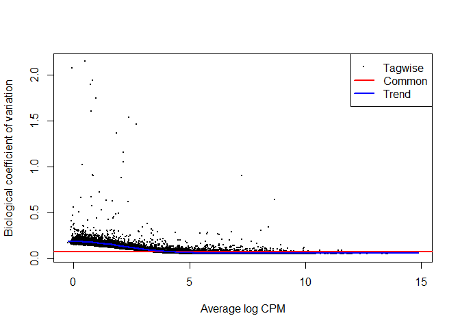

```r
# view the dispersion estimates
plotBCV(y1)
```

```r
# fit genewise GLMs
# tests are conducted for the last coefficient in the linear model (in this case the mMDSC vs Monocyte effect)
fit = glmQLFit(y1, design)
qlf = glmQLFTest(fit)

# show top 10 DEGs
topTags(qlf)
```

```
## Coefficient:  Cell.TypemMDSC
##               logFC    logCPM         F       PValue          FDR
## HLA-DPB1 -1.8531667  7.581591 1041.9807 1.822745e-11 2.250543e-07
## HLA-DPA1 -1.6694445  8.231758  862.3955 4.662766e-11 2.878558e-07
## HLA-DRA  -1.3264031 10.156656  591.5194 3.013445e-10 1.053312e-06
## HLA-DMA  -1.0074484  7.099943  576.8069 3.412364e-10 1.053312e-06
## CD74     -0.9042621 11.273444  533.6655 5.006820e-10 1.236384e-06
## RASA4    -1.2170478  5.553044  482.9175 8.189621e-10 1.685287e-06
## HLA-DRB1 -1.2582007  9.227446  408.7530 1.857575e-09 3.276496e-06
## PID1     -2.0625987  3.700865  377.7539 2.733691e-09 4.219110e-06
## CIITA    -0.7984906  6.847521  334.2871 4.968335e-09 6.816003e-06
## HLA-DRB3 -1.2195231  6.960131  301.2850 8.244636e-09 9.851064e-06
```

```r
summary(decideTests(qlf, adjust.method = "BH", p.value = 0.05))
```

```
##        Cell.TypemMDSC
## Down              747
## NotSig          10800
## Up                800
```

```r
summary(decideTests(qlf, adjust.method = "BH", p.value = 0.05, lfc = 1))
```

```
##        Cell.TypemMDSC
## Down               68
## NotSig          12249
## Up                 30
```

### Unpaired Design

This would be the setup if the data were not paired

```r
Cell.Type = factor(pheno$Cell.Type)
# design matrix
design.notpaired = model.matrix(~0+Cell.Type)
rownames(design.notpaired) = colnames(y)
design.notpaired
```

```
##     Cell.TypemMDSC Cell.Typemono Total or Med
## 1R               1                          0
## 2R               0                          1
## 7R               1                          0
## 8R               0                          1
## 20R              1                          0
## 21R              0                          1
## 27R              1                          0
## 28R              0                          1
## attr(,"assign")
## [1] 1 1
## attr(,"contrasts")
## attr(,"contrasts")$Cell.Type
## [1] "contr.treatment"
```

```r
# fit genewise GLMs
fit.notpaired = glmQLFit(y1, design.notpaired)
# need to create a contrast to make the comparison of interest
qlf.notpaired = glmQLFTest(fit.notpaired, contrast=c(1,-1))

# show top 10 DEGs
topTags(qlf.notpaired)
```

```
## Coefficient:  1*Cell.TypemMDSC -1*Cell.Typemono Total or Med
##               logFC      logCPM        F       PValue       FDR
## HLA-DRB1 -1.2732723  9.22744649 69.67677 1.334232e-05 0.1305416
## PADI4     1.1987517  7.08531081 57.33913 2.956384e-05 0.1305416
## SLCO4C1   1.3847152  3.29463004 52.51427 4.206737e-05 0.1305416
## TCF19    -1.9535543 -0.01689048 52.44454 4.229095e-05 0.1305416
## CD2      -1.9062709 -0.07521490 44.13869 8.342973e-05 0.2060214
## CPED1    -0.9434710  4.91594777 35.83580 1.851056e-04 0.3176451
## LRRC4     1.3499044  3.13222080 35.06232 2.008784e-04 0.3176451
## CD1C     -1.3228541  2.60564132 34.83545 2.058120e-04 0.3176451
## F5        0.8793338  7.78893085 31.38626 3.026397e-04 0.3265642
## ORM1      2.6861796  1.75326366 31.17449 3.102269e-04 0.3265642
```

## Plot Results

Using the paired design.

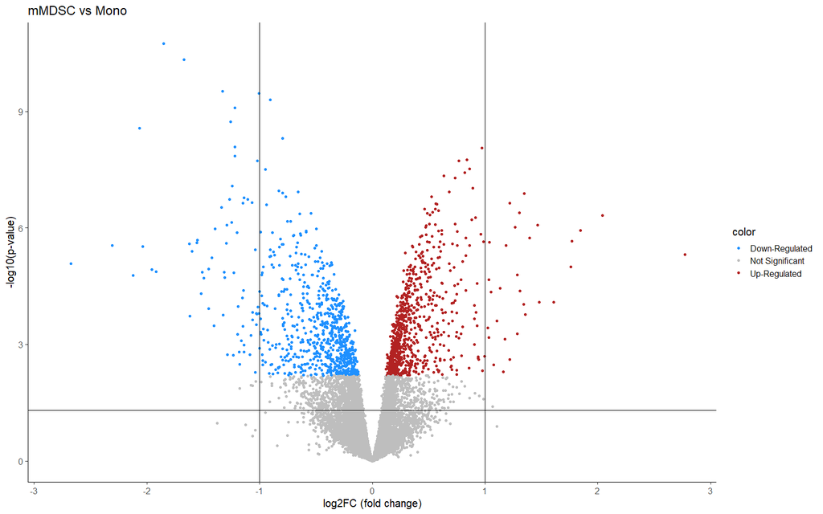

```r
range.x.y = c(0,1)
range.x.y[1] = max(abs(qlf$table$logFC))
range.x.y[2] = min(qlf$table$PValue)

# these are functions in the "utils_RNASeq.R" that are hopefully helpful for plotting
# volcano plot
plot.volcano(qlf, "mMDSC vs Mono", range.x.y, "mMDSC vs Mono")
```

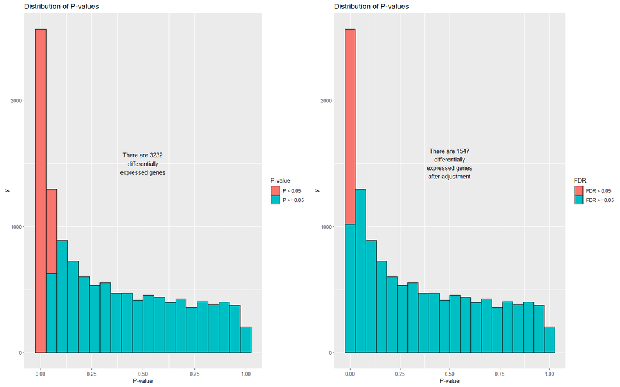

```r
# p-value histogram
plot.pval.hist(qlf, 0.5, 1500)
```

```r
# plot CPM boxplots of top N genes
N=15
o = order(qlf$table$PValue)

# by default the normalized library sizes are used in cpm
(topN = cpm(y1)[o[1:N],])
```

```
##                   1R          2R          7R         8R        20R        21R
## HLA-DPB1  146.552157  523.693120   70.451412  283.60493   66.80495  211.74045
## HLA-DPA1  222.486846  688.130984  126.562161  452.45332  129.27184  362.41209
## HLA-DRA  1000.115414 2480.717330  536.206700 1529.04969  594.20659 1304.58301
## HLA-DMA   132.781751  273.200458   81.118701  165.97136   83.98085  166.87040
## CD74     2271.379203 4441.053602 1530.899041 2979.39173 1690.90014 2898.38575
## RASA4      31.880023   81.442104   48.840776  110.98869   11.03731   24.91556
## HLA-DRB1  398.262208 1042.917259  341.814865  897.86360  333.25999  667.22840
## PID1       11.590346   47.996880    3.757008   12.45709    3.38729   16.08347
## CIITA     117.676662  213.309508  108.556293  186.54803   67.48387  112.65026
## HLA-DRB3   90.360786  241.023683  115.929176  280.69652   87.05131  174.13592
## CXCL8      40.924675   18.699362   48.906442   25.74024   81.93738   45.64313
## FN1         3.873804    8.704359   11.487623   27.99177  823.87537 1628.92314
## PADI2     222.188126  111.752272  420.425518  226.37535  363.78327  219.32638
## S100A8   3339.841810 1705.248672 3430.834266 2122.03350 4783.58354 3008.29994
## HLA-DQB1  179.212736  425.120847  246.029785  472.34732  242.49580  427.06670
##                  27R         28R
## HLA-DPB1   48.193384  180.332547
## HLA-DPA1   98.158362  324.580663
## HLA-DRA   475.237809 1210.620753
## HLA-DMA    65.307890  127.404332
## CD74     1385.056829 2605.337826
## RASA4      20.699434   45.685938
## HLA-DRB1  329.883261  783.591070
## PID1        1.231108    6.183342
## CIITA      41.544498   73.061118
## HLA-DRB3    2.163147    4.629441
## CXCL8     131.458339   65.955651
## FN1        40.426892  110.526496
## PADI2     320.928900  193.027815
## S100A8   3875.348591 2314.870095
## HLA-DQB1   81.868698  173.959822
```

```r
topN = as.data.frame(t(topN))
topN$Cell.Type = pheno$Cell.Typ
topN.long = gather(topN, gene, cpm, 1:N, factor_key = T)
```

```
## Note: Using an external vector in selections is ambiguous.
## i Use `all_of(N)` instead of `N` to silence this message.
## i See <https://tidyselect.r-lib.org/reference/faq-external-vector.html>.
```

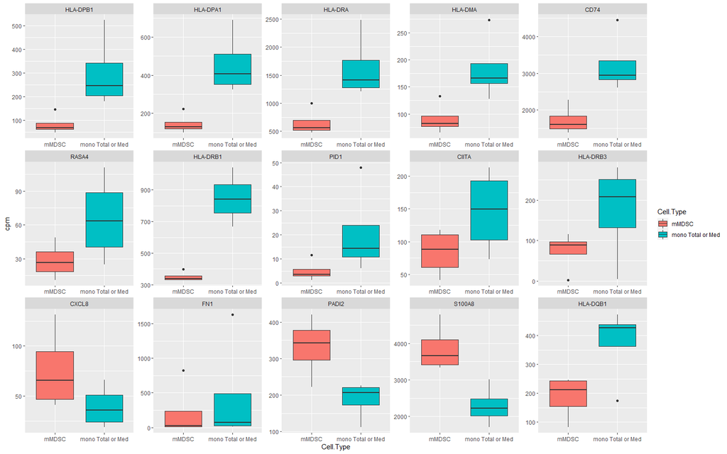

```r
topN.long %>%
  ggplot(aes(x = Cell.Type, y = cpm, fill = Cell.Type)) +
  geom_boxplot() +
  facet_wrap(vars(gene), scales = "free", ncol = 5)
```

# Gene Set Enrichment

## Reactome Pathways

```r
gene.list = qlf$table$logFC
names = read.csv("rsem_gene_symbols_entrez.csv")
names = subset(names, SYMBOL%in%rownames(qlf$table))
# Names of gene list must be Entrez IDs
names(gene.list) = names$ENTREZID
# Sort in decreasing order
gene.list = sort(gene.list, decreasing = T)

gseReactome = gsePathway(gene = gene.list, pvalueCutoff = 0.05)
```

```
## preparing geneSet collections...
```

```
## GSEA analysis...
```

```
## leading edge analysis...
```

```
## done...
```

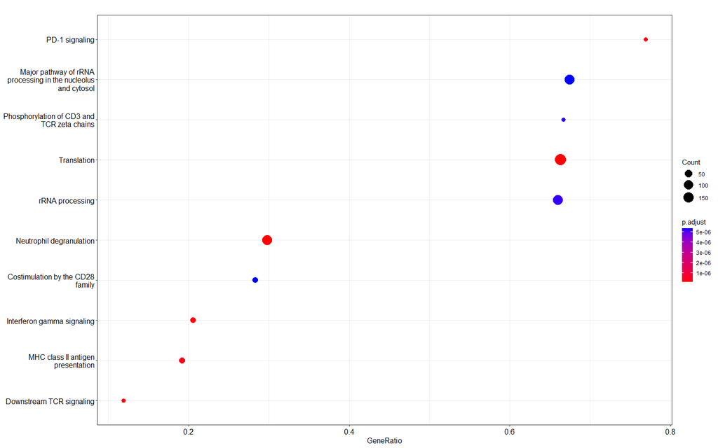

```r
dotplot(gseReactome)
```

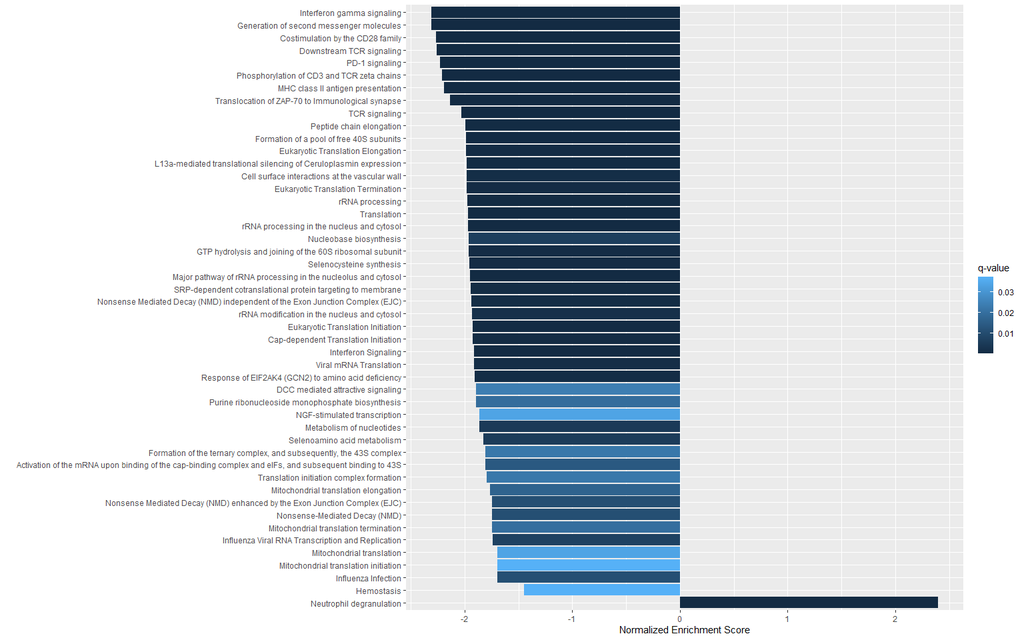

```r
# plot Normalized Enrichment Score
plot.bar.NES(gseReactome@result, gseReactome@result$qvalues, "q-value")
```